# Statistics Package Exercise: Exploring Simple Random Samples

Sam Matuba

9/4/2019

## Background

Population: all (1129) students with different majors (business, social sciences, or natural sciences) at a large university taking introductory statistics courses

Variables:

- **Course**: natural science, social science, or business
- **Handed**: handedness (right-handed vs left-handed)
- **Sex**: male or female
- **Verbal**: SAT Verbal scores up to 800
- **Age**: in yers

Methods: - Take a random sample and use sample summaries as estimates for population summaries. Would the sample estimates provide unbiased estimates for the population value? - Sample 192 business students and intuit if they would be a representative sample.

Notes: - all students have options in terms when to take the course - women, on the whole, do better than men on the verbal portion of SAT - business is a major that tends to interest males more than females

## Goals

A. Verify the distributions of the variables for the sample and the population

B. Intuit whether the distributions of each variable in the sample of business students would be rougly similar to the population

C. Check B.

## R

Load dataset

```r
load(file="student_survey.RData")
```

```r
head(population)
```

```
##    Course Handed    Sex Verbal   Age
## 1  Social   left   male    470 18.83
## 2  Social  right female    650 18.67
## 3  Social  right   male    580 20.08
## 4  Social  right female    660 18.50
## 5  Social  right female    790 24.25
## 6  Social  right female    640 20.33
```

Take a simple random sample of data. For consistency, the sample will have the same size (192) as the nonrandom sample of business statistics students.

```r
random_sample = population[sample(length(population$Course),192),]; head(random_sample)
```

```
##        Course Handed    Sex Verbal   Age
## 90    Natural  right   male    700 19.33
## 569    Social  right female    640 23.83
## 132   Natural  right   male    650 20.17
## 302    Social  right   male    620 20.00
## 227   Natural  right female    700 19.25
## 1006 Business  right   male     NA 18.33
```

### Part A

Create bar charts or pie charts and compare the distribution of the variables in the sample and in the population.

#### Handedness

```r
random_sample_percent = 100*prop.table(table(random_sample$Handed));random_sample_percent
```

```
##
##     left    right
## 13.54167 86.45833
```

```r
pop_percent = 100*prop.table(table(population$Handed));pop_percent
```

```
##
##     left    right
## 13.28609 86.71391
```

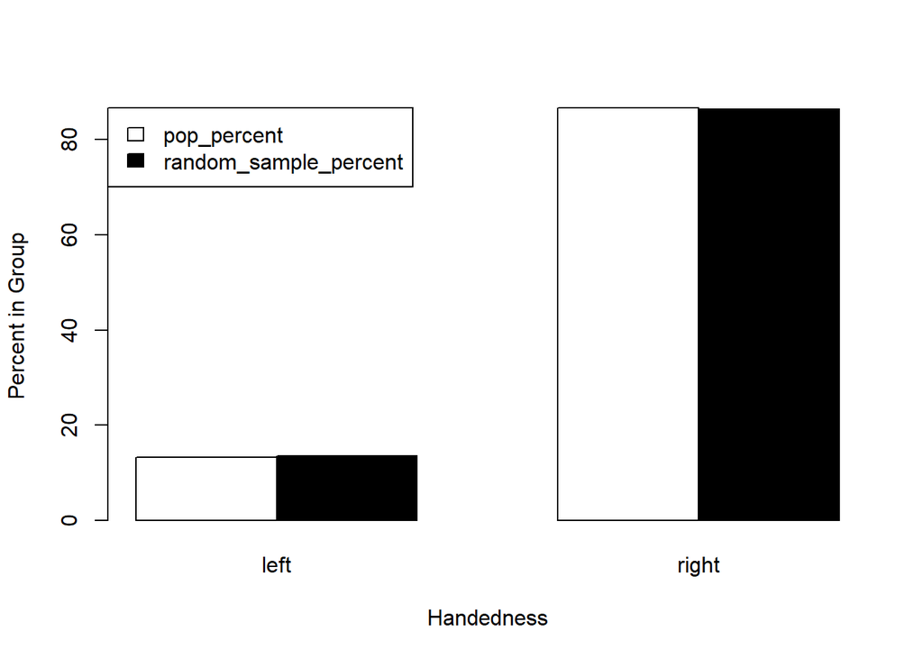

```r
barplot(rbind(pop_percent,random_sample_percent), beside=T, col=c(0,1),legend.text=T,xlab="Handedness",ylab="Percent in Group",args.legend=list(x="topleft"))
```

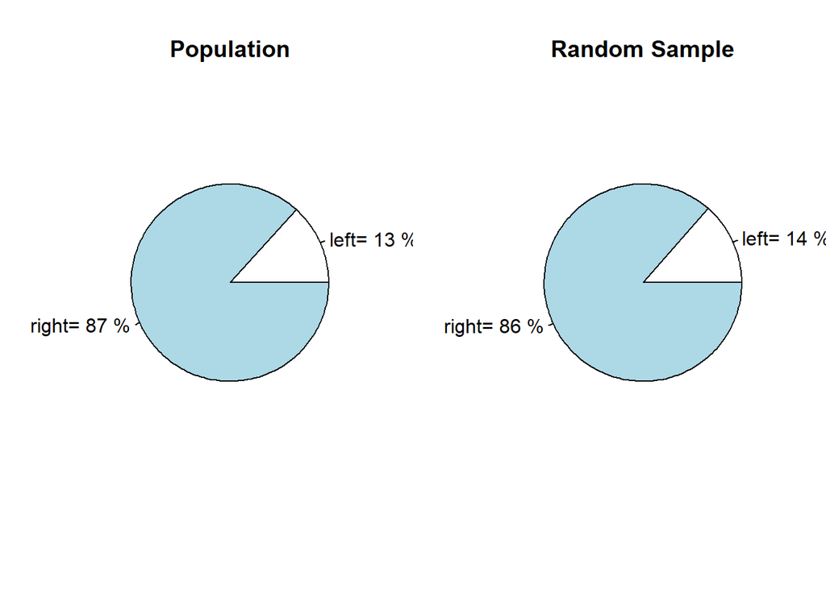

```r
par(mfrow=c(1,2)); pie(pop_percent,labels=paste(c("left=","right="),round(pop_percent,0),"%"),main="Population"); pie(random_sample_percent,labels=paste(c("left=","right="),round(random_sample_percent,0),"%"),main="Random Sample")
```

In comparing the two charts, we see that the distribution of the handedness for sample comes within 5% of the distribution for the population.

#### Sex

```r
random_sample_percent = 100*summary(random_sample$Sex)/length(random_sample$Sex);random_sample_percent;
```

```
##   female     male
## 61.45833 38.54167
```

```r
pop_percent = 100*summary(population$Sex)/length(population $Sex);pop_percent;
```

```
##   female     male
## 62.09035 37.90965
```

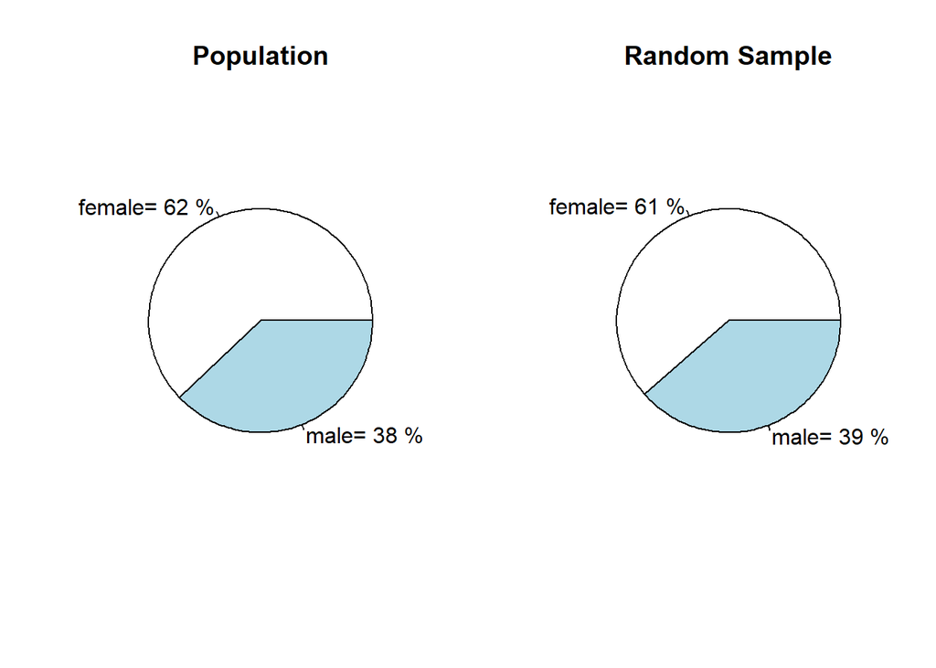

```r
par(mfrow=c(1,2));
pie(pop_percent,labels=paste(c("female=","male="),round(pop_percent,0),"%"),main="Population"); pie(random_sample_percent,labels=paste(c("female=","male="),round(random_sample_percent,0),"%"),main="Random Sample")
```

In the Sex variable, the distribution of the sample also falls within 5% to that of the population.

#### SAT Verbal Scores

```r
summary(population$Verbal)
```

```
##    Min. 1st Qu.  Median    Mean 3rd Qu.    Max.    NA's
##   300.0   540.0   590.0   588.8   640.0   800.0     131
```

```r
summary(random_sample$Verbal)
```

```
##    Min. 1st Qu.  Median    Mean 3rd Qu.    Max.    NA's
##     420     540     600     594     650     800      19
```

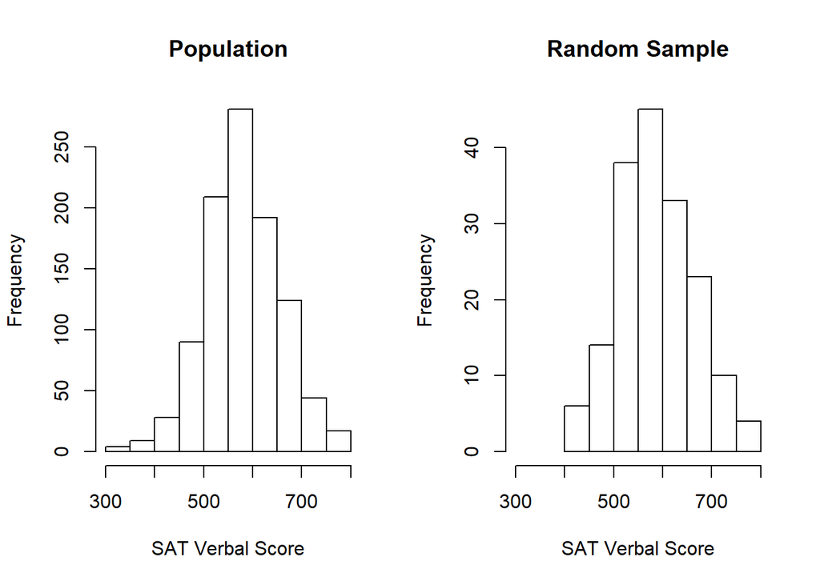

```r
par(mfrow=c(1,2));
hist(population$Verbal,main="Population",xlab="SAT Verbal Score",xlim=range(300,800));
hist(random_sample$Verbal,main="Random Sample",xlab="SAT Verbal Score",xlim=range(300,800));
```

Since SAT scores tend to follow a normal (symmetric) distribution, we can compare the mean of the sample to that of the population.

```r
random_sample_SAT_mean = 595
pop_SAT_mean =  588.8
percent_difference = 100*(random_sample_SAT_mean - pop_SAT_mean)/(pop_SAT_mean); percent_difference
```

```
## [1] 1.052989
```

#### Age

```r
summary(population$Age)
```

```
##    Min. 1st Qu.  Median    Mean 3rd Qu.    Max.    NA's
##   17.67   19.08   19.67   20.37   20.67   74.17       6
```

```r
summary(random_sample$Age)
```

```
##    Min. 1st Qu.  Median    Mean 3rd Qu.    Max.    NA's
##   17.92   19.00   19.67   20.36   20.83   74.17       3
```

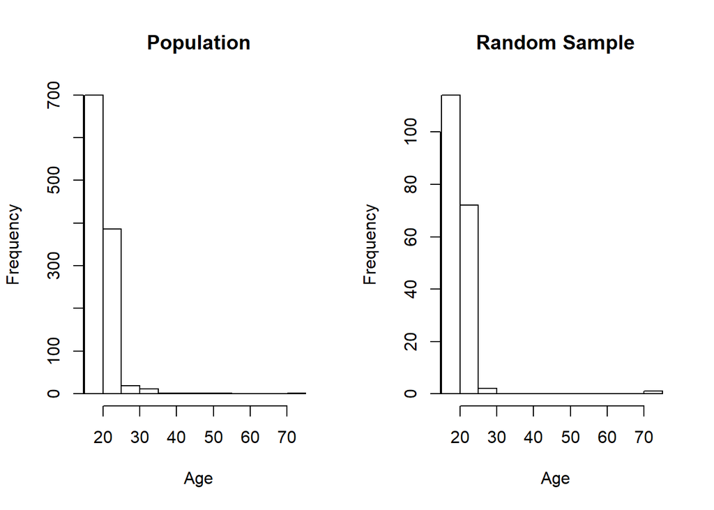

```r
par(mfrow=c(1,2));
hist(population$Age,main="Population",xlab="Age",xlim=range(17,75));
hist(random_sample$Age,main="Random Sample",xlab="Age",xlim=range(17,75));
```

Since Age tends to follow a right-skewed distribution, the medians could be compared. It turns out, that the median is 19.67 for both sample and population.

## Intuit whether the distributions of each of the four variables in the (nonrandom) sample of business students would be roughly the same as those for the population, or whether there is a reason to expect any of them to be biased. For each of the variables—Handed, Sex, Verbal, and Age—decide whether or not you believe the sample of business statistics students should be fairly representative of the larger population of all students in introductory statistics courses.

For the nonrandom sample of 192 business students, we can outright expect that the distribution of the Sex variable will not be representative of the population since business as a major tend to interest more males than females. Consequently, the distribution of Verbal SAT score will also be not representative since there are less number of females than males in the sample but females in general get higher scores than males. As for Handedness and Age, we can intuit that the type of major should not substantially affect the distribution compared to that of the population.

## How representative is the (nonrandom) sample of students in the business statistics course, in actuality? In order to answer this question, we will need to extract this group from the population.

```r
business = population[population$Course=="Business",];business
```

[output not shown]

[output cut: 178 more lines]

#### Handedness

```r
business_percent = 100*summary(business$Handed)/length(business$Handed);business_percent;
```

```
##   left  right
##  9.375 90.625
```

```r
pop_percent = 100*prop.table(table(population$Handed));pop_percent
```

```
##
##     left    right
## 13.28609 86.71391
```

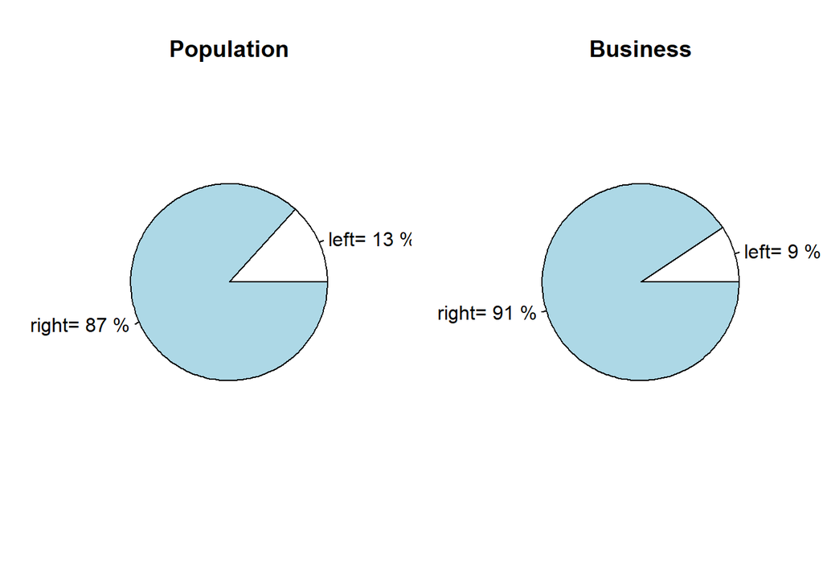

```r
par(mfrow=c(1,2));
pie(pop_percent,labels=paste(c("left=","right="),round(pop_percent,0),"%"),main="Population"); pie(business_percent,labels=paste(c("left=","right="),round(business_percent,0),"%"),main="Business")
```

In comparing the distribution for Handed between population and business sample, the percentages are still within 5%.

#### Sex

```r
business_percent = 100*summary(business$Sex)/length(business$Sex);business_percent;
```

```
##   female     male
## 52.08333 47.91667
```

```r
pop_percent = 100*summary(population$Sex)/length(population $Sex);pop_percent;
```

```
##   female     male
## 62.09035 37.90965
```

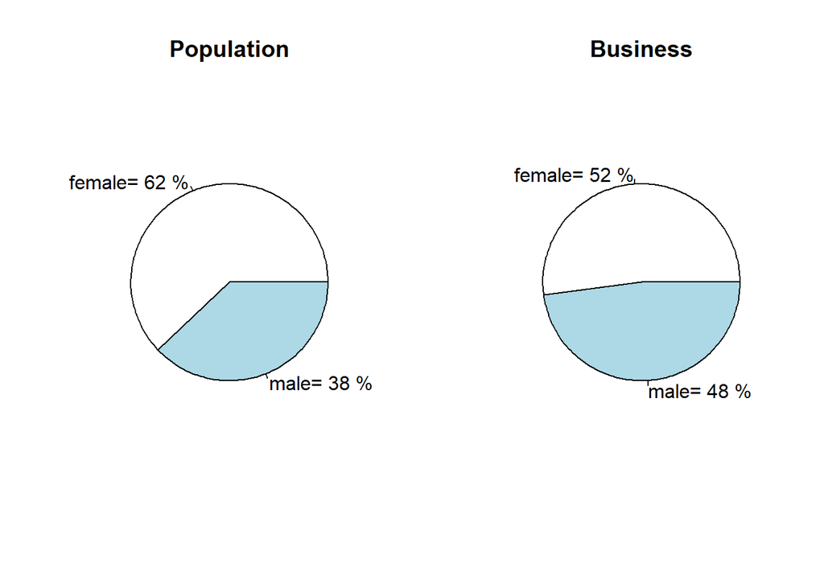

```r
par(mfrow=c(1,2));
pie(pop_percent,labels=paste(c("female=","male="),round(pop_percent,0),"%"),main="Population"); pie(business_percent,labels=paste(c("female=","male="),round(business_percent,0),"%"),main="Business")
```

In comparing the distribution for Sex between population and business sample, the percentage of females is substantially less in the business sample than that of the population sample by ten percent. This is an expected from the background of the problem.

#### Verbal

```r
summary(business$Verbal)
```

```
##    Min. 1st Qu.  Median    Mean 3rd Qu.    Max.    NA's
##   340.0   530.0   580.0   574.6   620.0   760.0      21
```

```r
summary(population$Verbal)
```

```
##    Min. 1st Qu.  Median    Mean 3rd Qu.    Max.    NA's
##   300.0   540.0   590.0   588.8   640.0   800.0     131
```

```r
100*abs((mean(business$Verbal,na.rm=TRUE) - mean(population$Verbal,na.rm=TRUE))/mean(population$Verbal,na.rm=TRUE))
```

```
## [1] 2.40012
```

We determined previously that the SAT Verbal scores tend to have a normal (symettric) distribution. By comparing the means of 574.6 and 588.8 in the business sample and population, respectively, there is only a 2.4% difference.

#### Age

```r
summary(business$Age)
```

```
##    Min. 1st Qu.  Median    Mean 3rd Qu.    Max.
##   17.67   18.83   19.50   20.31   20.25   74.17
```

```r
summary(population$Age)
```

```
##    Min. 1st Qu.  Median    Mean 3rd Qu.    Max.    NA's
##   17.67   19.08   19.67   20.37   20.67   74.17       6
```

For the numerical variable Age, we previously found that the distribution tends to be right-skewed. Hence, the medians are compared. With medians 19.50 and 19.67, we can say that there is no bias for this variable in the business sample.

#### Summary

Going back to the intuition, it was correct that the Sex variables is expected to be biased. For the Verbal scores, however, it turned out to not make a significant difference. The variables Age and Handed turned out to be unbiased as expected.